# Case Study 2: University tuition

Kelly Bodwin

## Get the data

We will be attempting to find a linear regression that models college tuition rates, based on a dataset from US News and World Report. Alas, this data is from 1995, so it is very outdated; still, we will see what we can learn from it.

### Question 1:

1. The dataset is located at `http://kbodwin.web.unc.edu/files/2016/09/tuition_final.csv`; figure out how to use the code you were given last time for `read.csv( )` and `read.table( )` to read the data into **R** and call it `tuition`. Use the functions we learned last time to familiarize yourself with the data in `tuition`.

```r
tuition = read.csv("http://kbodwin.web.unc.edu/files/2016/09/tuition_final.csv")
summary(tuition)
```

```
##        ID                       Name          State         Public
##  Min.   : 1002   Bethel College   :   4   NY     :101   Min.   :1.000
##  1st Qu.: 1874   Concordia College:   4   PA     : 83   1st Qu.:1.000
##  Median : 2650   Trinity College  :   4   CA     : 70   Median :2.000
##  Mean   : 3126   Columbia College :   3   TX     : 60   Mean   :1.639
##  3rd Qu.: 3431   Union College    :   3   MA     : 56   3rd Qu.:2.000
##  Max.   :30431   Augustana College:   2   OH     : 52   Max.   :2.000
##                  (Other)          :1282   (Other):880
##     Avg.SAT          Avg.ACT         Applied           Accepted
##  Min.   : 600.0   Min.   :11.00   Min.   :   35.0   Min.   :   35.0
##  1st Qu.: 884.5   1st Qu.:20.25   1st Qu.:  695.8   1st Qu.:  554.5
##  Median : 957.0   Median :22.00   Median : 1470.0   Median : 1095.0
##  Mean   : 968.0   Mean   :22.12   Mean   : 2752.1   Mean   : 1870.7
##  3rd Qu.:1038.0   3rd Qu.:24.00   3rd Qu.: 3314.2   3rd Qu.: 2303.0
##  Max.   :1410.0   Max.   :31.00   Max.   :48094.0   Max.   :26330.0
##  NA's   :523      NA's   :588     NA's   :10        NA's   :11
##       Size        Out.Tuition       Spending
##  Min.   :   59   Min.   : 1044   Min.   : 1834
##  1st Qu.:  966   1st Qu.: 6111   1st Qu.: 6116
##  Median : 1812   Median : 8670   Median : 7729
##  Mean   : 3693   Mean   : 9277   Mean   : 8988
##  3rd Qu.: 4540   3rd Qu.:11659   3rd Qu.:10054
##  Max.   :31643   Max.   :25750   Max.   :62469
##  NA's   :3       NA's   :20      NA's   :39
```

```r
head(tuition)
```

```
##      ID                              Name State Public Avg.SAT Avg.ACT
## 1  1061         Alaska Pacific University    AK      2     972      20
## 2  1063 University of Alaska at Fairbanks    AK      1     961      22
## 3  1065    University of Alaska Southeast    AK      1      NA      NA
## 4 11462 University of Alaska at Anchorage    AK      1     881      20
## 5  1002       Alabama Agri. & Mech. Univ.    AL      1      NA      17
## 6  1003               Faulkner University    AL      2      NA      20
##   Applied Accepted Size Out.Tuition Spending
## 1     193      146  249        7560    10922
## 2    1852     1427 3885        5226    11935
## 3     146      117  492        5226     9584
## 4    2065     1598 6209        5226     8046
## 5    2817     1920 3958        3400     7043
## 6     345      320 1367        5600     3971
```

```r
tail(tuition)
```

```
##        ID                                  Name State Public Avg.SAT
## 1297 3825 West Virginia Institute of Technology    WV      1      NA
## 1298 3826           West Virginia State College    WV      1      NA
## 1299 3827              West Virginia University    WV      1     946
## 1300 3830        West Virginia Wesleyan College    WV      2     928
## 1301 3831               Wheeling Jesuit College    WV      2     912
## 1302 3932                 University of Wyoming    WY      1      NA
##      Avg.ACT Applied Accepted  Size Out.Tuition Spending
## 1297      20    1594     1572  2432          NA     4325
## 1298      18    1869       NA  2817        4616     3839
## 1299      22    9630     7801 14524        6370     8318
## 1300      23    1566     1400  1509       14200     8080
## 1301      22     903      755   971       10500     7494
## 1302      23    2029     1516  7535        5988     8745
```

```r
ncol(tuition)
```

```
## [1] 11
```

```r
nrow(tuition)
```

```
## [1] 1302
```

2. Make a new variable in `tuition` called `Acc.Rate` that contains the acceptance rate for each university.

```r
tuition$Acc.Rate = tuition$Accepted / tuition$Applied
```

3. Find and print the row of the data that corresponds to UNC (“University of North Carolina at Chapel Hill”).

```r
UNC=tuition[tuition$Name == "University of North Carolina at Chapel Hill", ]
print(UNC)
```

```
##       ID                                        Name State Public Avg.SAT
## 682 2974 University of North Carolina at Chapel Hill    NC      1    1121
##     Avg.ACT Applied Accepted  Size Out.Tuition Spending  Acc.Rate
## 682      NA   14596     5985 14609        8400    15893 0.4100438
```

## Writing functions

We have seen many examples of using functions in **R**, like `summary( )` or `t.test( )`. Now you will learn how to write your *own* functions. Defining a function means writing code that looks something like this:

```r
my_function <- function(VAR_1, VAR_2){

  # do some stuff with VAR_1 and VAR_2
  return(result)

}
```

Then you run the code in **R** to “teach” it how your function works, and after that, you can use it like you would any other pre-existing function. For example, try out the following:

```r
add1 <- function(a, b){

  # add the variables
  c = a + b
  return(c)

}

add2 <- function(a, b = 3){

  # add the variables
  c = a + b
  return(c)

}

# Try adding 5 and 7
add1(5, 7)
add2(5, 7)

# Try adding one variable
add1(5)
add2(5)
```

### Question 2:

What was the effect of `b = 3` in the definition of `add2( )`?

[output not shown]

### Question 3:

1. Recall that the equations for simple linear regression are:
   $$\beta_1 = r \frac{S_Y}{S_X} \hspace{0.5cm} \beta_0 = \bar{Y} - \beta_1 \bar{X}$$

Write your own functions, called `beta1( )` and `beta0( )` that take as input some combination of `Sx`, `Sy`, `r`, `y_bar`, and `x_bar`, and use that to calculate $\beta_1$ and $\beta_0$.

```r
beta1 <- function(r, Sx, Sy) {
  if (Sx > 0) {
    b1 = r * Sy / Sx
    return(b1)
  } else {
    b1 = NA
    print("Sx = 0, cannot calculate b1")
    return(b1)
  }
}

beta0 <- function(y_bar, beta1, x_bar) {
  if (is.na(beta1)) {
    b0 = NA
    print("beta1 does not exist, cannot calculate b0")
    return(b0)
  } else {
    b0 = y_bar - beta1 * x_bar
    return(b0)
  }
}
```

2. Try your function with `Sx = 0`. Did it work? If not, fix your function code. Explain why it would be a problem to do linear regression with $S_X = 0$.

```
In the equation 'b1 = r * Sy / Sx', Sx is denominator which cannot be zero. The equation does not have meaning at 'Sx = 0'. If 'Sx = 0', the computer will fail to calculate the equation. Aslo, 'Sx = 0' means all data have the same x value, which has no practical meaning as well.
```

## Linear Regression by hand

Use the code below to make a scatterplot of college tuition versus average SAT score.

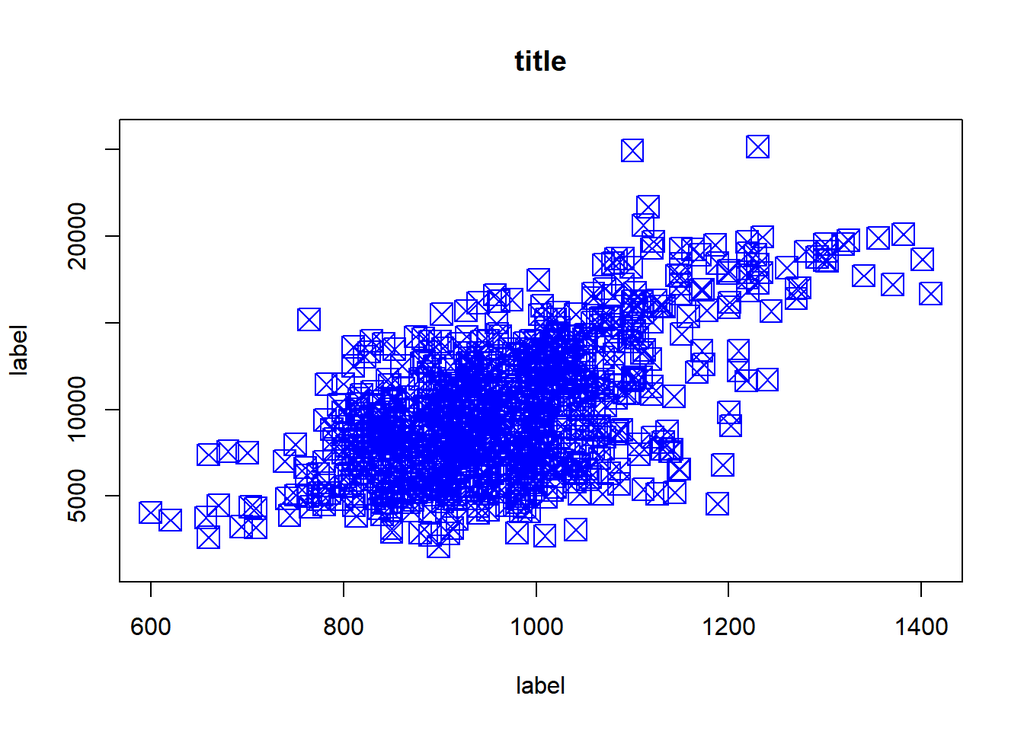

```r
plot(tuition$Avg.SAT, tuition$Out.Tuition, main = "title", xlab = "label", ylab = "label", pch = 7, cex = 2, col = "blue")
```

### Question 4:

1. Make your own scatterplot, but change the input of `plot( )` so that it looks nice.

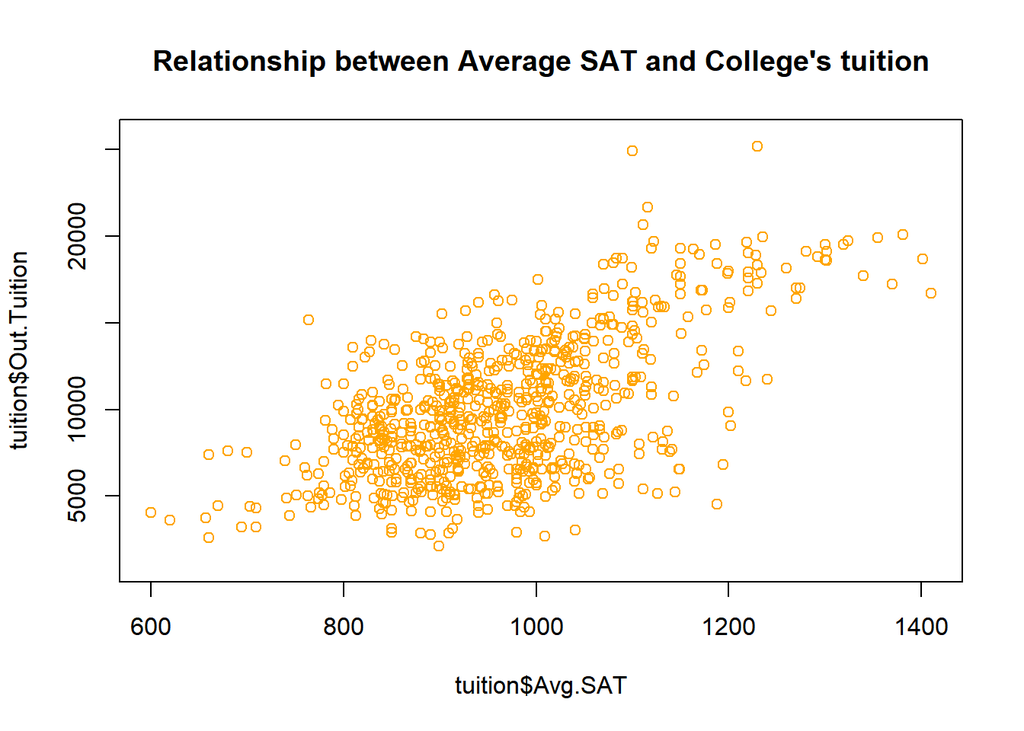

```r
plot(tuition$Avg.SAT, tuition$Out.Tuition, main = "Relationship between Average SAT and College's tuition", xlab = "tuition$Avg.SAT", ylab = "tuition$Out.Tuition", pch = 1, cex = 1, col = "orange")
```

2. What do `pch` and `cex` do?

```
The 'pch' is plotting charcter, using graphics symbols to represent a single character or an interger coder. Different number input of 'pch' is for different graphic symbols.
The 'cex' is used to scale the size of graphic symbols of 'pch', and 'cex = 1' is the default value.
```

3. We have used the function `abline( )` to add a vertical line or a horizontal line to a graph. However, it can also add lines by slope and intercept. Read the documentation of `abline( )` until you understand how to do this. Then add a line with slope 10 and intercept 0 to your plot.

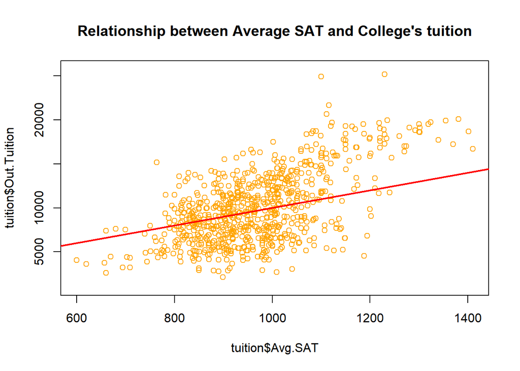

```r
plot(tuition$Avg.SAT, tuition$Out.Tuition, main = "Relationship between Average SAT and College's tuition", xlab = "tuition$Avg.SAT", ylab = "tuition$Out.Tuition", pch = 1, cex = 1, col = "orange")
abline(a = 0, b = 10, untf = FALSE, col = "red", lwd = 2)
```

4. Does this line seem to fit the data well?

```
Based on the graph above, the line does not fit the data very well, because most of the points are far away from the line. The slope shoud be larger, and the intercept should be smaller.
```

### Question 5:

1. Use the functions you already know in **R** and the ones you created, `beta1( )` and `beta0( )`, to find the slope and intercept for a regression line of `Avg.SAT` on `Out.Tuition`. Remake your scatterplot, and add the regression line.

*(Hint: You may have some trouble finding the mean and sd because there is some missing data. Look at the documentation for the functions you use. What could we add to the function arguments to ignore values of `NA`?)*

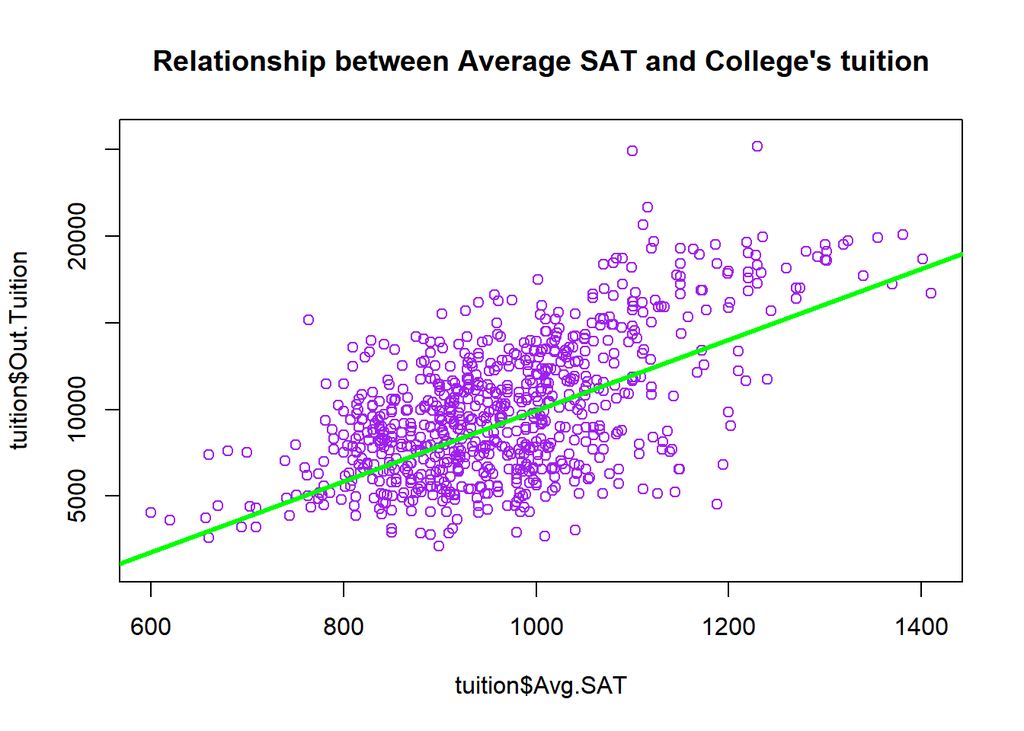

```r
xi = tuition$Avg.SAT
yi = tuition$Out.Tuition
x_bar = mean(tuition$Avg.SAT, na.rm = TRUE)
y_bar = mean(tuition$Out.Tuition, na.rm = TRUE)
r = cor(xi, yi, use = "complete.obs")
Sx = sd(xi, na.rm = TRUE)
Sy = sd(yi, na.rm = TRUE)
b1 = beta1(r, Sx, Sy)
b0 = beta0(y_bar, beta1(r, Sx, Sy), x_bar)
plot(tuition$Avg.SAT, tuition$Out.Tuition, main = "Relationship between Average SAT and College's tuition", xlab = "tuition$Avg.SAT", ylab = "tuition$Out.Tuition", pch = 1, cex = 1, col = "purple")
abline(a = b0, b = b1, untf = FALSE, col = "green", lwd = 3)
```

2. What do you conclude about the relationship between average SAT score and a college’s tuition?

```
As shown by the output above, average SAT score and college's tuition has a positive correlation. That is to say, the higher average SAT score, the higher college's tuition.
```

### Question 6:

1. Write a new function called `predict_yval(X, Y, x_new)` that takes as input a vector of explanatory variables (`X`), a vector of y-variables (`Y`), and a new x-value that we want to predict (`x_new`). The output of the function should be the predicted y-value for `x_new` from a regression line. *(Hint: You can use functions inside functions.)*

```r
predict_yval <- function(X, Y, x_new) {
  x_bar = mean(X, na.rm = TRUE)
  y_bar = mean(Y, na.rm = TRUE)
  r = cor(X, Y, use = "complete.obs")
  Sx = sd(X, na.rm = TRUE)
  Sy = sd(Y, na.rm = TRUE)
  b1 = beta1(r, Sx, Sy)
  b0 = beta0(y_bar, beta1(r, Sx, Sy), x_bar)
  y_new = b0 + b1 * x_new
  return(y_new)
}
```

2. Now find the average SAT score and tuition of UNC and of Duke, and compare their predicted values to the truth:

```r
x_UNC_score = tuition$Avg.SAT[tuition$Name == "University of North Carolina at Chapel Hill"]
print(x_UNC_score)
```

```
## [1] 1121
```

```r
y_UNC_tuition = tuition$Out.Tuition[tuition$Name == "University of North Carolina at Chapel Hill"]
print(y_UNC_tuition)
```

```
## [1] 8400
```

```r
y_UNC_predicted = predict_yval(tuition$Avg.SAT, tuition$Out.Tuition, x_UNC_score)
print(y_UNC_predicted)
```

```
## [1] 12410.22
```

```r
x_Duke_score = tuition$Avg.SAT[tuition$Name == "Duke University"]
print(x_Duke_score)
```

```
## [1] 1302
```

```r
y_Duke_tuition = tuition$Out.Tuition[tuition$Name == "Duke University"]
print(y_Duke_tuition)
```

```
## [1] 18590
```

```r
y_Duke_predicted = predict_yval(tuition$Avg.SAT, tuition$Out.Tuition, x_Duke_score)
print(y_Duke_predicted)
```

```
## [1] 16116.43
```

3. Would you say you are getting a deal at UNC? How about at Duke?

```
As for the UNC, its predicted tuition is 12410.22, which is much larger than the true tuition, 8400, so I get a deal at UNC, because I pay less than predicted. As for Duke, its predicted tuition is 16116.43, which is lower than the true tuition, 18590. That is to say I need to pay more than predicted, so I do not get a deal at Duke.
```

### `lm()` and diagnostics

You now have functions to calculate the slope and intercept of a linear regression, and to predict values. As you might expect, **R** was already able to do this, using the function `lm( )`. In class, you saw how to read the output of `lm( )`. Run the following regression of `Avg.SAT` on `Out.Tuition`, and refamiliarize yourself with the output.

```r
  # Make linear model
  my_lm = lm(Out.Tuition ~ Avg.SAT, data = tuition)
  summary(my_lm)
```

```
##
## Call:
## lm(formula = Out.Tuition ~ Avg.SAT, data = tuition)
##
## Residuals:
##     Min      1Q  Median      3Q     Max
## -9809.9 -2234.6   204.6  2309.3 12336.3
##
## Coefficients:
##               Estimate Std. Error t value Pr(>|t|)
## (Intercept) -9173.7964   914.3482  -10.03   <2e-16 ***
## Avg.SAT        19.7977     0.9379   21.11   <2e-16 ***
## ---
## Signif. codes:  0 '***' 0.001 '**' 0.01 '*' 0.05 '.' 0.1 ' ' 1
##
## Residual standard error: 3183 on 765 degrees of freedom
##   (535 observations deleted due to missingness)
## Multiple R-squared:  0.3681, Adjusted R-squared:  0.3673
## F-statistic: 445.6 on 1 and 765 DF,  p-value: < 2.2e-16
```

Check out `names(my_lm)`. This will give you a list of information we can access using `$`. For example, compare `my_lm$coefficents` to your `beta1` and `beta0` outputs.

```r
  names(my_lm)
```

```
##  [1] "coefficients"  "residuals"     "effects"       "rank"
##  [5] "fitted.values" "assign"        "qr"            "df.residual"
##  [9] "na.action"     "xlevels"       "call"          "terms"
## [13] "model"
```

```r
  my_lm$coefficients
```

```
## (Intercept)     Avg.SAT
##  -9173.7964     19.7977
```

```r
  print(b0)
```

```
## [1] -10543.7
```

```r
  print(b1)
```

```
## [1] 20.47629
```

[output not shown]

The output of `lm( )` is made to play nicely with other functions in **R**. For example, try adding `abline(my_lm)` to your scatterplot. We can also use `lm( )` to check some common diagnostics, to see if the linear model is a good fit for the data. Try `plot(my_lm)`, and familiarize yourself with the first three plots that are automatically generated. (The fourth is not covered in this course, so you do not need to worry about it for now.)

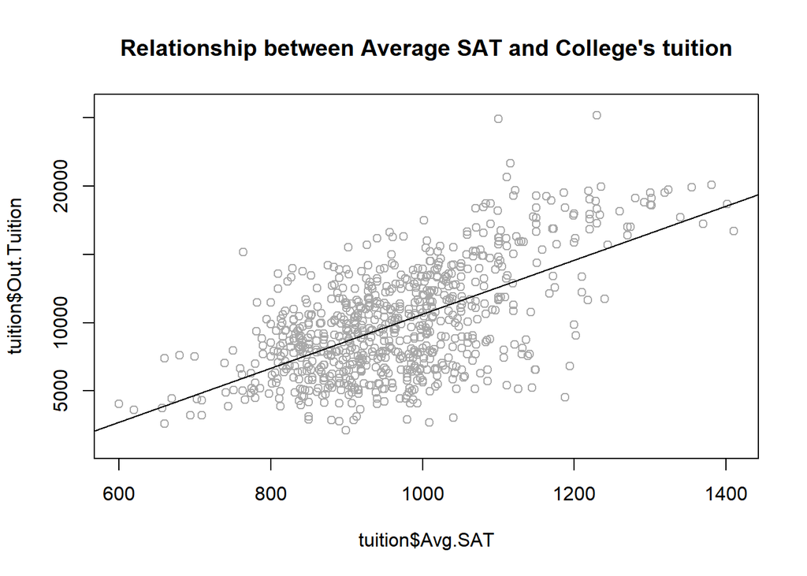

```r
  plot(tuition$Avg.SAT, tuition$Out.Tuition, main = "Relationship between Average SAT and College's tuition", xlab = "tuition$Avg.SAT", ylab = "tuition$Out.Tuition", pch = 1, cex = 1, col = "darkgrey")
  abline(my_lm)
```

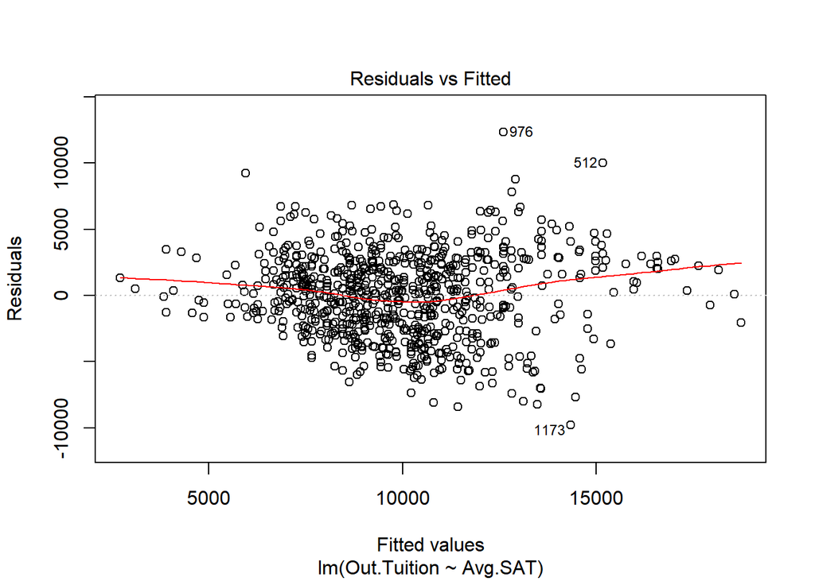

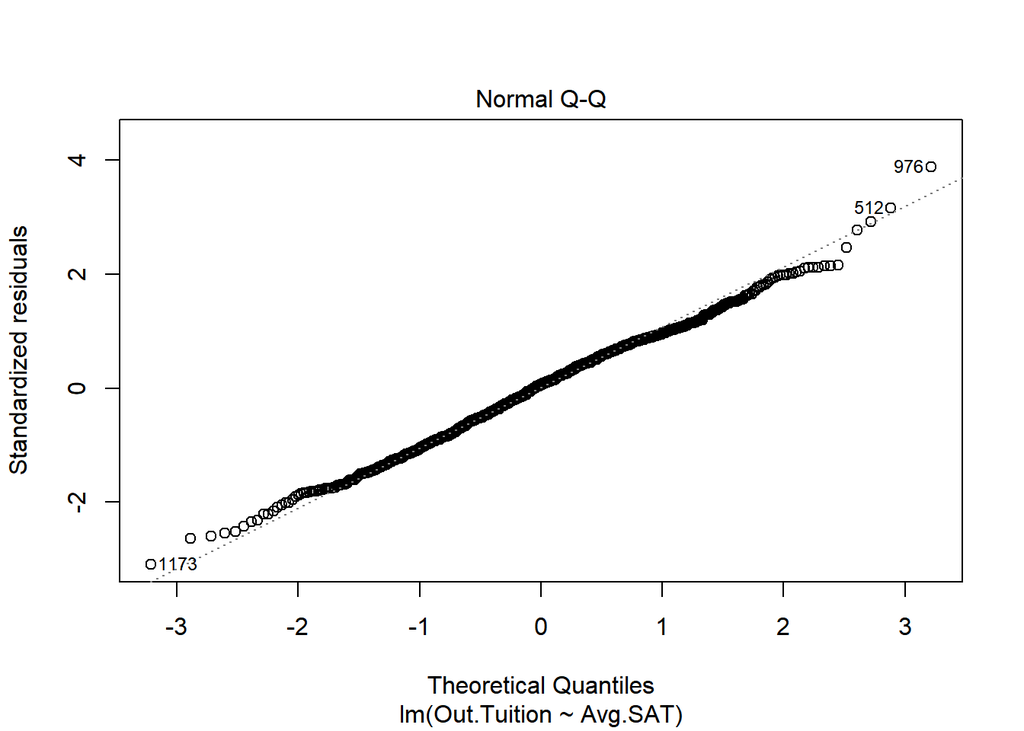

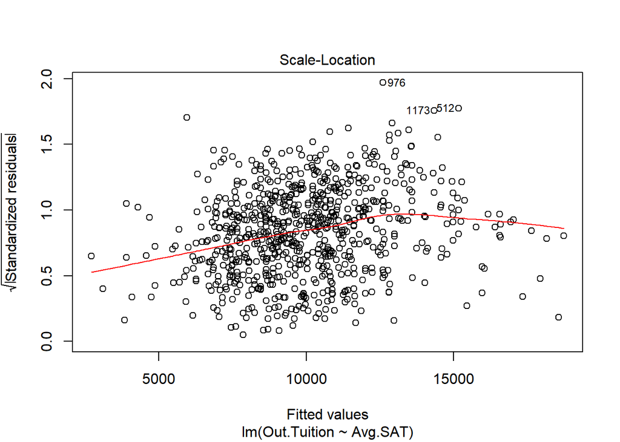

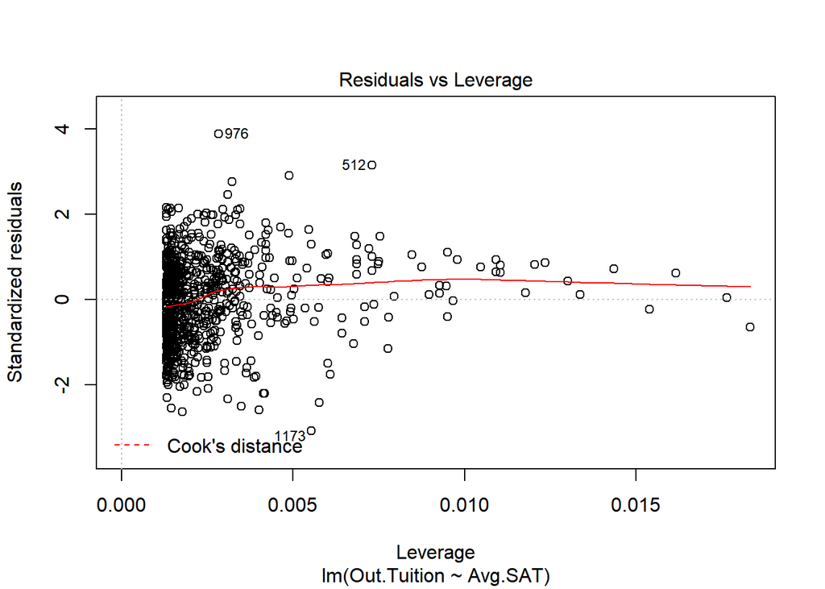

```r
  plot(my_lm)
```

***

## Question 7:

1. The variable `Spending` contains the expenditure of the school per student. Suppose we want to make a regression that predicts tuition cost from the expenditure per student. Make a linear model for `Spending` versus `Out.Tuition`. Comment on the summary of the model, and plot it on an appropriate scatter plot. Does the model seem to be a good fit for this data?

```r
  sp_lm <- lm(Out.Tuition ~ Spending, data = tuition)
  summary(sp_lm)
```

```
##
## Call:
## lm(formula = Out.Tuition ~ Spending, data = tuition)
##
## Residuals:
##      Min       1Q   Median       3Q      Max
## -22023.7  -2205.4    -99.9   2020.6  11804.0
##
## Coefficients:
##              Estimate Std. Error t value Pr(>|t|)
## (Intercept) 4.477e+03  1.792e+02   24.98   <2e-16 ***
## Spending    5.481e-01  1.752e-02   31.29   <2e-16 ***
## ---
## Signif. codes:  0 '***' 0.001 '**' 0.01 '*' 0.05 '.' 0.1 ' ' 1
##
## Residual standard error: 3126 on 1242 degrees of freedom
##   (58 observations deleted due to missingness)
## Multiple R-squared:  0.4409, Adjusted R-squared:  0.4404
## F-statistic: 979.3 on 1 and 1242 DF,  p-value: < 2.2e-16
```

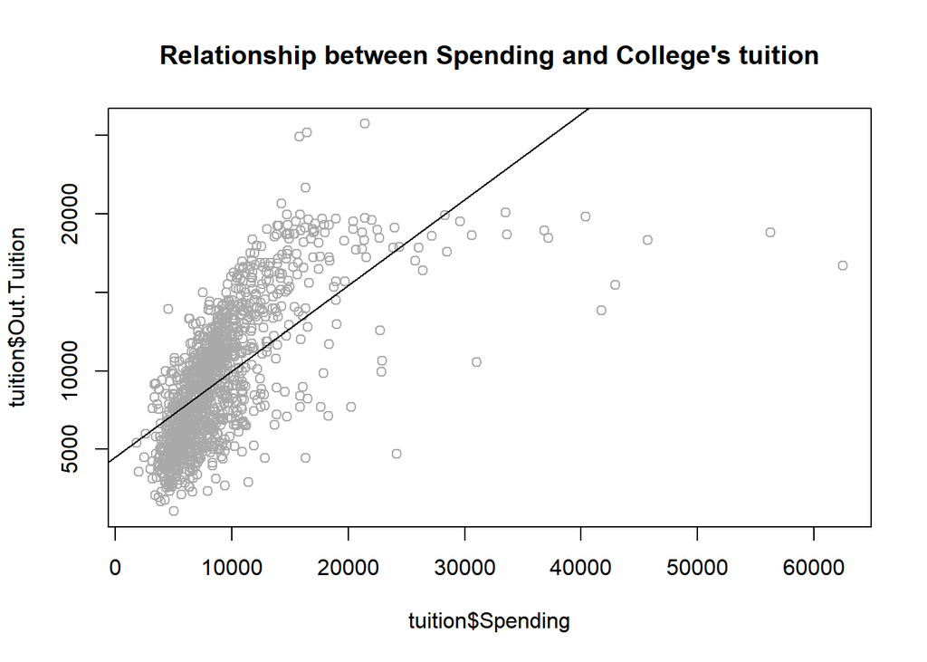

```
According to the "summary(sp_lm)", the p-value of beta0 and beta1 is smaller than 2e-16, which means there is significant evidence supporting that the slope and intercept of the regression line are not eqaul to zero. Therefore, there is a regression model between Spending and College's Tuition.

However, based on the scatter plots output, the model is not a good fit, because the linear fit is overly influenced by some outliers at the right end of the data.
```

```r
  plot(tuition$Spending, tuition$Out.Tuition, main = "Relationship between Spending and College's tuition", xlab = "tuition$Spending", ylab = "tuition$Out.Tuition", pch = 1, cex = 1, col = "darkgrey" )
  abline(sp_lm)
```

2. Plot the residuals versus the values of `Spending`. Do you notice any issues? *Hint: Use your own function `predict_yval()` or the built-in function `predict(my_lm)`. You will need to think about the problem of missing data (`NA`s).*

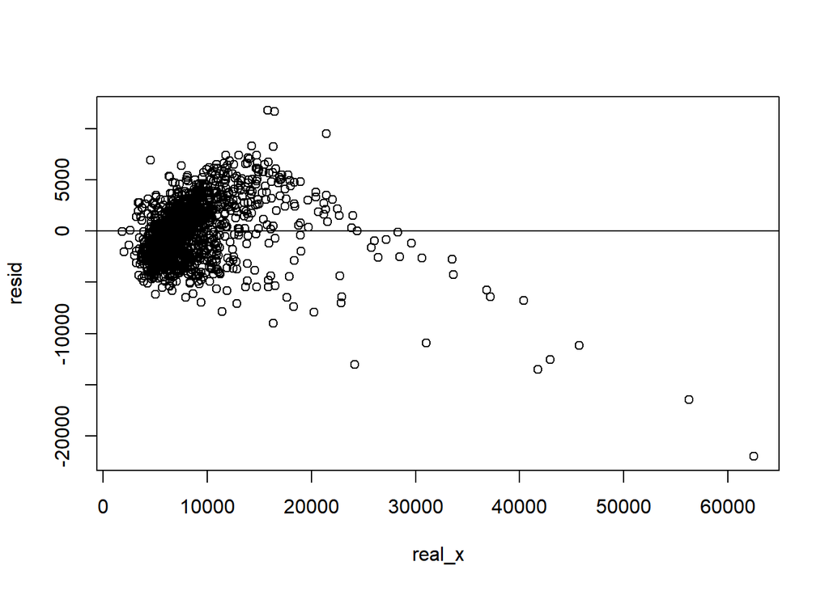

```
The points of the residual plot scatter together and do not scatter randomly.
```

```r
  real_y <- tuition$Out.Tuition[order(tuition$Spending)]
  real_x <- tuition$Spending[order(tuition$Spending)]
  new_x = data.frame(Spending=tuition$Spending[order(tuition$Spending)])
  sp_lm <- lm(Out.Tuition ~ Spending, data = tuition)
  resid <- real_y - predict(sp_lm, newdata = new_x)
  plot(real_x, resid)
  abline(h=0)
```

3. Use `plot()` to look at the automatic diagnostics. What is each plot showing? What seems to be going wrong here? Which schools are marked as outliers?

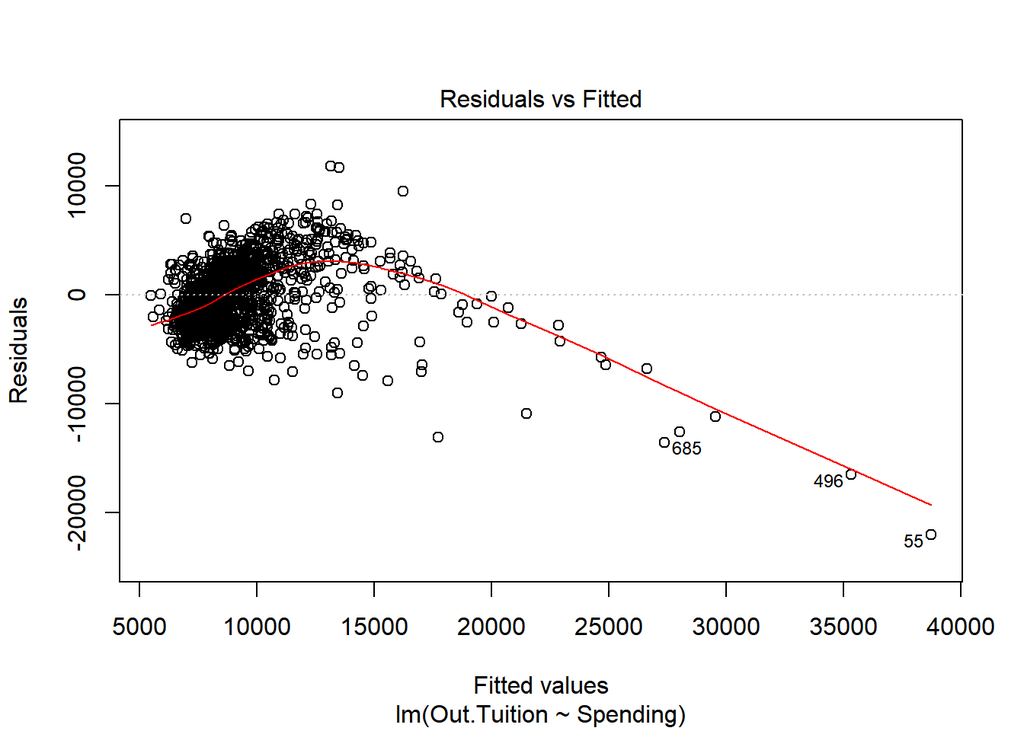

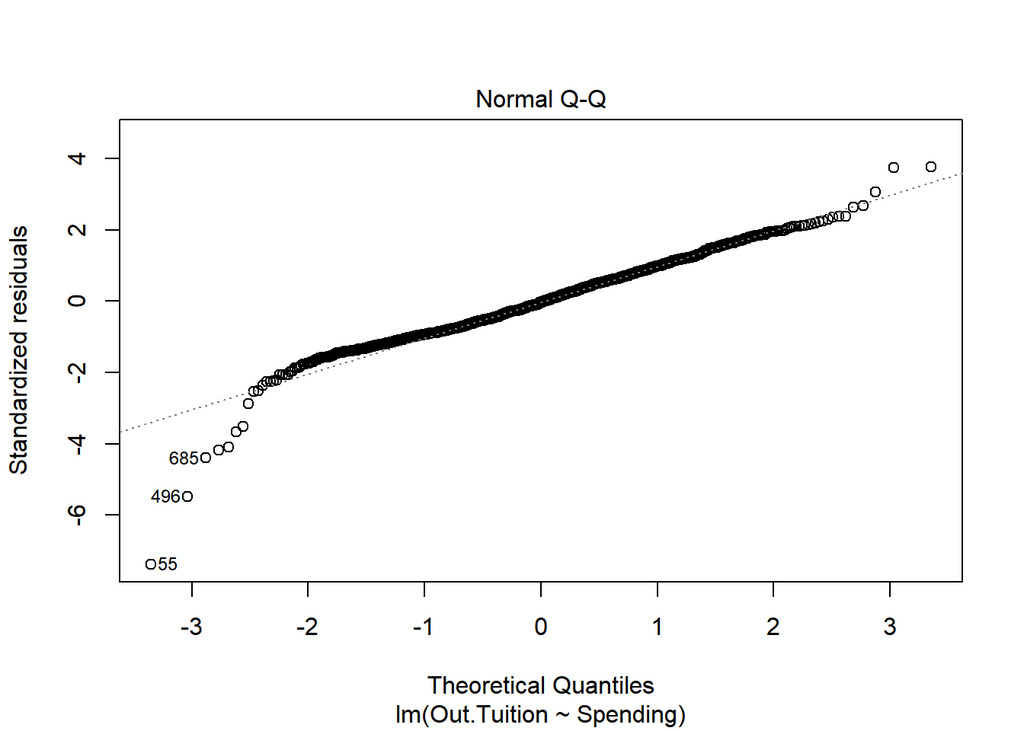

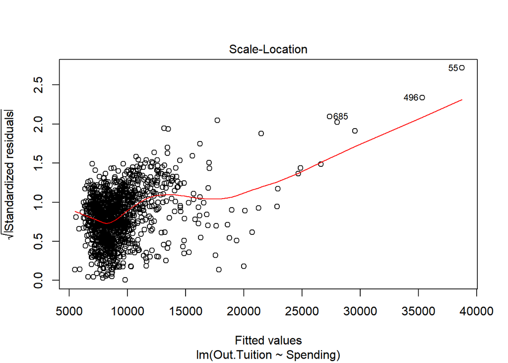

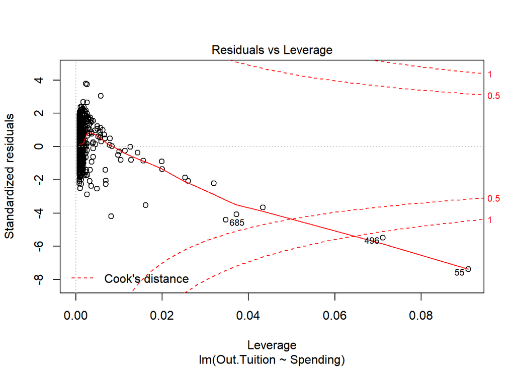

```r
  plot(sp_lm)
```

```r
  print(tuition$Name[55])
```

```
## [1] California Institute of Technology
## 1274 Levels: Abilene Christian University ... Youngstown State University
```

```r
  print(tuition$Name[496])
```

```
## [1] Johns Hopkins University
## 1274 Levels: Abilene Christian University ... Youngstown State University
```

```r
  print(tuition$Name[685])
```

```
## [1] Wake Forest University
## 1274 Levels: Abilene Christian University ... Youngstown State University
```

[output not shown]

4. Roughly speaking, an outlier is “influential” if it changes the regression line when you remove it. Decide for yourself which data points are influential outliers. Recalculate the linear model without any outliers, and plot it on a scatterplot.

```r
  tuition_new = tuition[-c(55, 496, 685), ]
  sp_lm_new = lm(tuition_new$Out.Tuition ~ tuition_new$Spending)
  summary(sp_lm_new)
```

```
##
## Call:
## lm(formula = tuition_new$Out.Tuition ~ tuition_new$Spending)
##
## Residuals:
##      Min       1Q   Median       3Q      Max
## -15782.0  -2006.8    -67.3   1998.1  11102.7
##
## Coefficients:
##                       Estimate Std. Error t value Pr(>|t|)
## (Intercept)          3.693e+03  1.837e+02   20.10   <2e-16 ***
## tuition_new$Spending 6.421e-01  1.858e-02   34.56   <2e-16 ***
## ---
## Signif. codes:  0 '***' 0.001 '**' 0.01 '*' 0.05 '.' 0.1 ' ' 1
##
## Residual standard error: 2976 on 1239 degrees of freedom
##   (58 observations deleted due to missingness)
## Multiple R-squared:  0.4909, Adjusted R-squared:  0.4904
## F-statistic:  1195 on 1 and 1239 DF,  p-value: < 2.2e-16
```

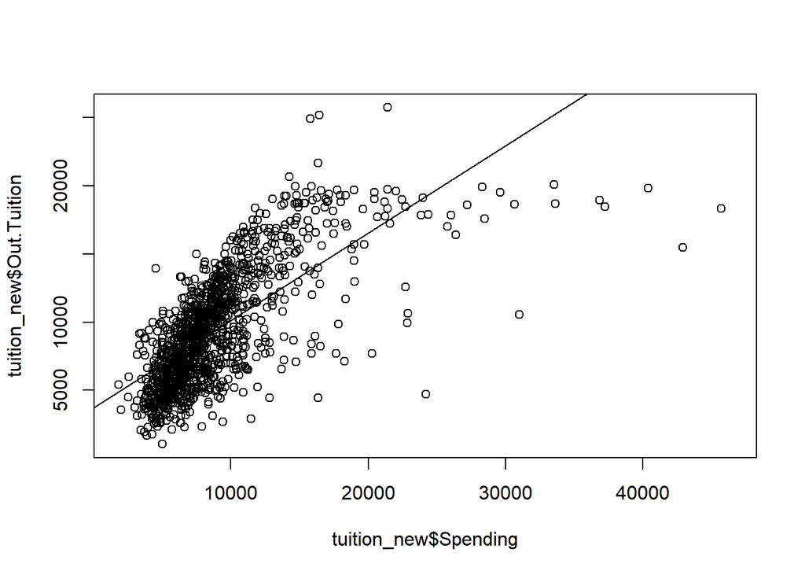

```r
  plot(tuition_new$Spending, tuition_new$Out.Tuition)
  abline(sp_lm_new)
```

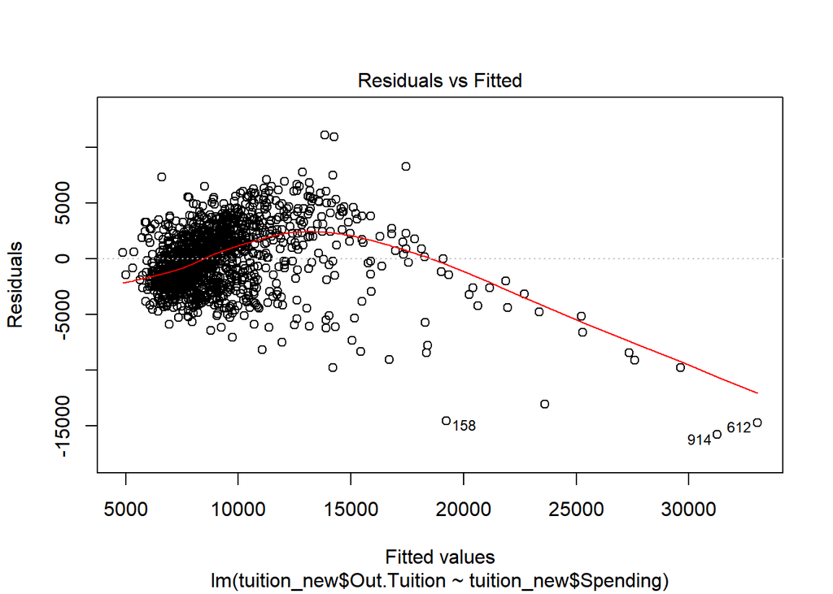

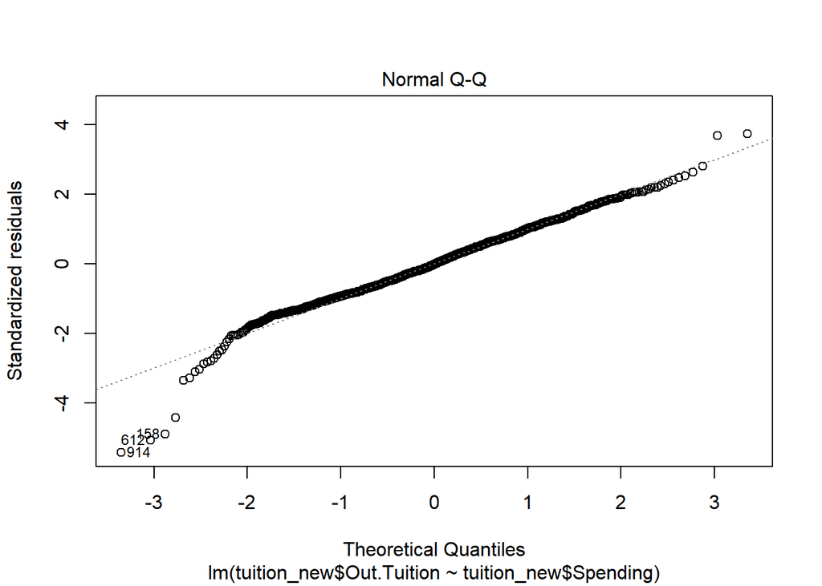

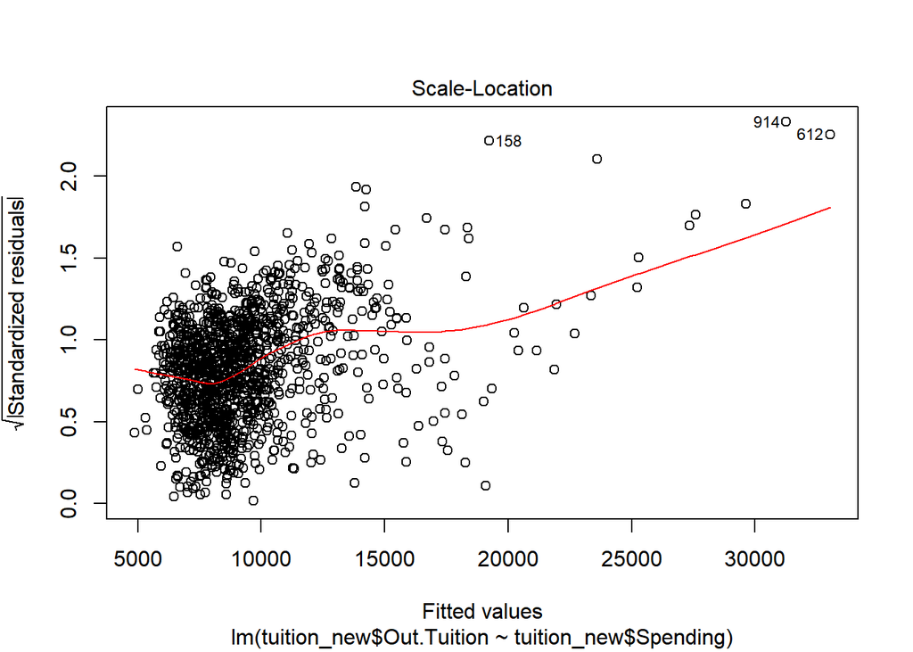

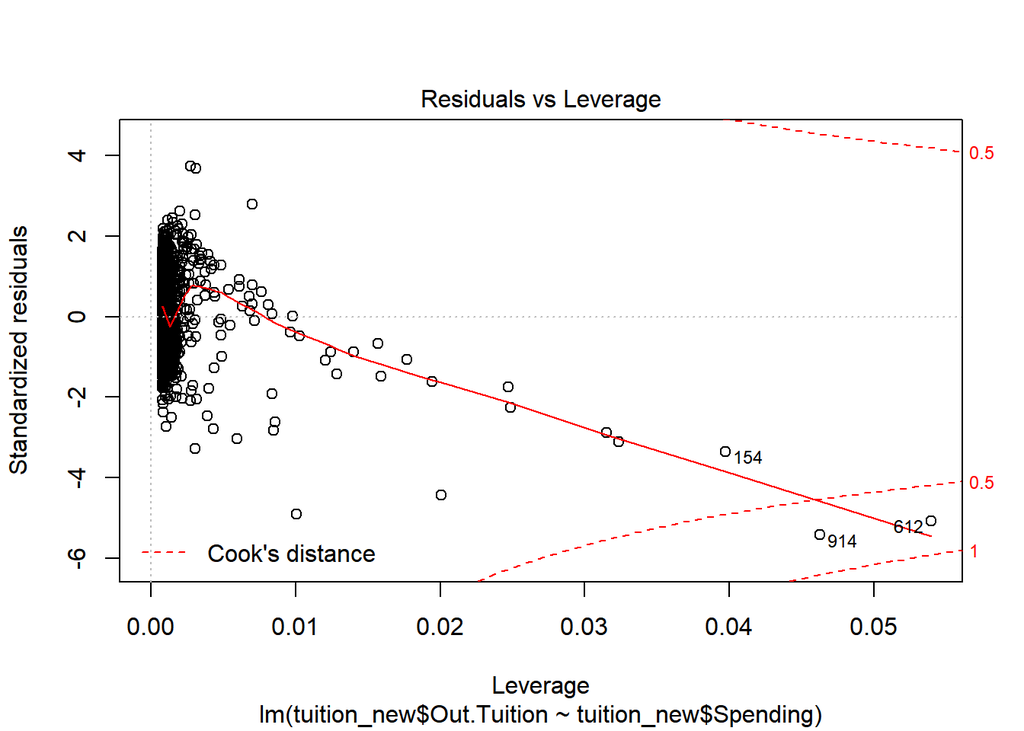

```r
  plot(sp_lm_new)
```

### Question 8:

1. Now suppose we want to make a regression that predicts tuition cost from the size of the student body. Make a linear model for `Size` versus `Out.Tuition`. Comment on the summary of the model, and plot it on an appropriate scatter plot, and use `plot( )` to look at the diagnostics. Does the model seem to be a good fit for this data?

```r
  sz_lm = lm(tuition$Out.Tuition ~ tuition$Size)
  summary(sz_lm)
```

```
##
## Call:
## lm(formula = tuition$Out.Tuition ~ tuition$Size)
##
## Residuals:
##     Min      1Q  Median      3Q     Max
## -7899.0 -3081.2  -550.1  2347.0 16194.3
##
## Coefficients:
##                Estimate Std. Error t value Pr(>|t|)
## (Intercept)  9883.96074  147.77601  66.885  < 2e-16 ***
## tuition$Size   -0.16284    0.02514  -6.477 1.33e-10 ***
## ---
## Signif. codes:  0 '***' 0.001 '**' 0.01 '*' 0.05 '.' 0.1 ' ' 1
##
## Residual standard error: 4107 on 1278 degrees of freedom
##   (22 observations deleted due to missingness)
## Multiple R-squared:  0.03179,    Adjusted R-squared:  0.03103
## F-statistic: 41.96 on 1 and 1278 DF,  p-value: 1.329e-10
```

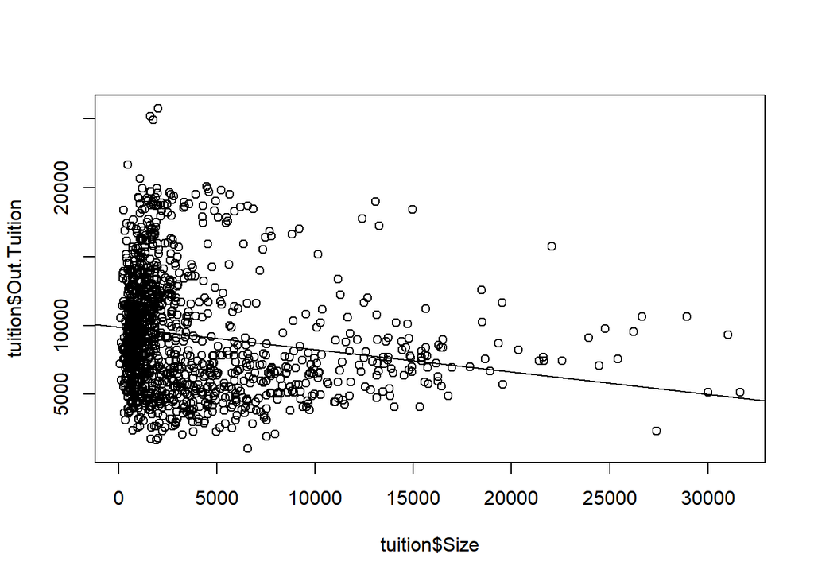

```r
  plot(tuition$Size, tuition$Out.Tuition)
  abline(sz_lm)
```

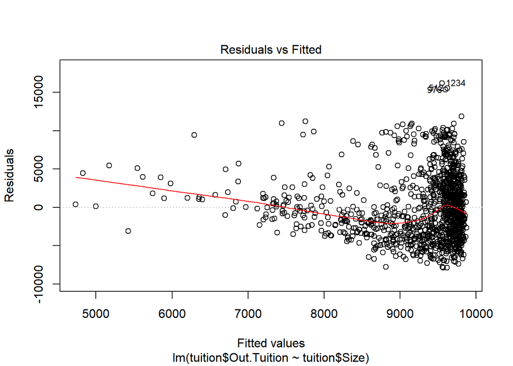

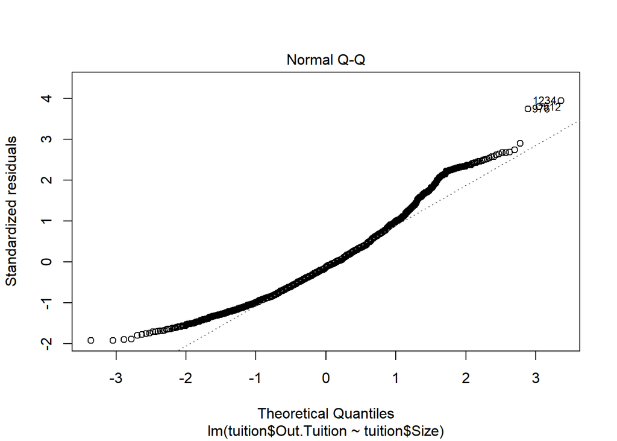

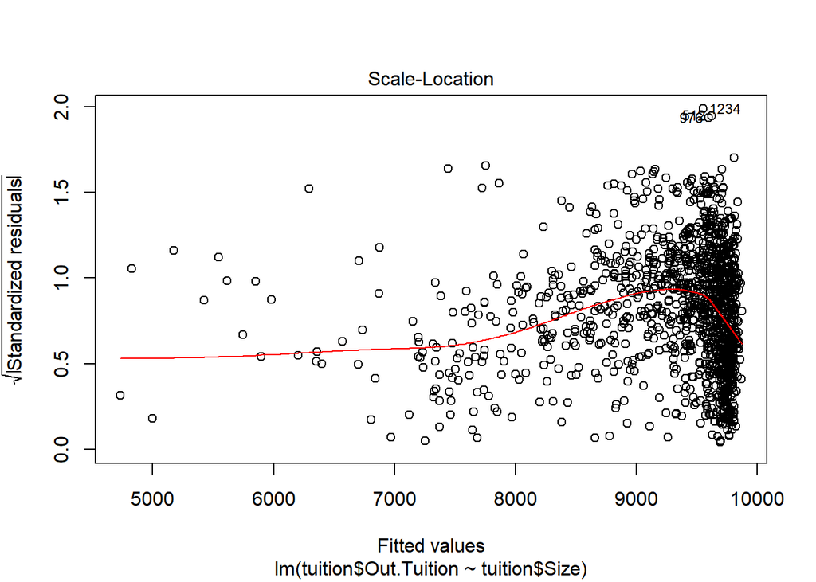

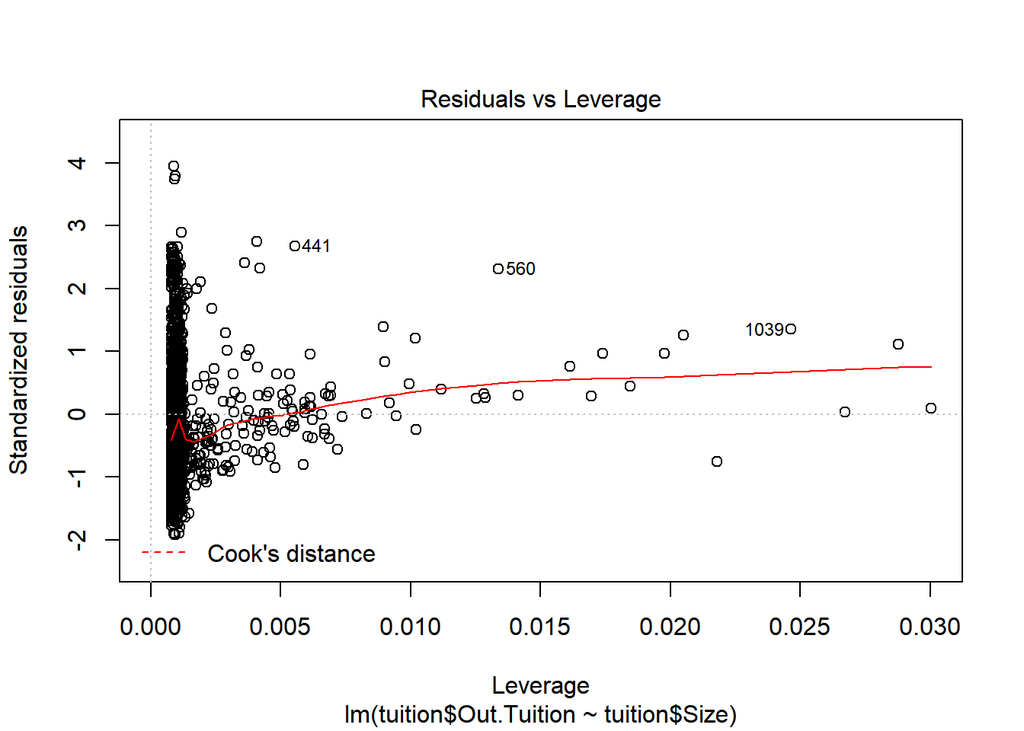

```
According to "summary(sz_lm)", the p-value of beta0 and beta1 is much less than 0.001, which means there is significant evidence supporting that the slope and intercept of the regression line exist, and there is a linear model between Size and Out.Tuition.

However, based on the plots output, residuals are not normally distributed (Q-Q plot) and do not have the same variance for each X (points do not scatter randomly in 'Residuals vs Fitted' and 'Scale-Location). Moreover, there are several outliers based on Residuals vs Leverage.

Therefore, the model is not a good fit for this data.
```

```r
  plot(sz_lm)
```

2. Remake your scatterplot, this time including the option `col = tuition$Public`. What did this change? Can you use this information to explain why the regression line in (a) did not fit well?

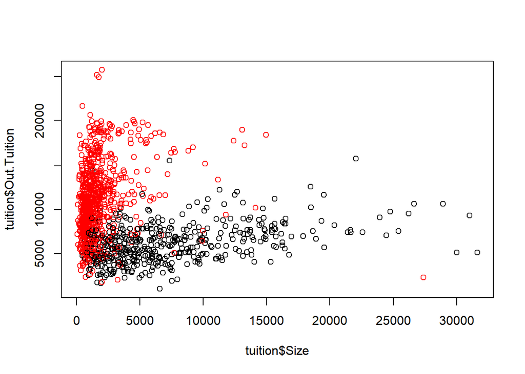

```
The 'col = tuition$Public' seperates all the colleges into two groups, public schools and private schools, by using different color.

The reason why regression line in (a) did not fit well is because most private schools' Out.tuition vaires little according to their size.
```

```r
  plot(tuition$Size, tuition$Out.Tuition, col = tuition$Public)
```

3. Make separate linear regressions of `Size` versus `Out.Tuition` for private schools and for public schools. Plot both of these, appropriately colored, on your scatterplot. Comment on the output and diagnostics.

```r
  tuition_public = tuition[tuition$Public == 1, ]
  sz_pu = lm(tuition_public$Out.Tuition ~ tuition_public$Size)
  summary(sz_pu)
```

```
##
## Call:
## lm(formula = tuition_public$Out.Tuition ~ tuition_public$Size)
##
## Residuals:
##     Min      1Q  Median      3Q     Max
## -4998.1 -1297.3  -181.9  1021.3  9355.3
##
## Coefficients:
##                      Estimate Std. Error t value Pr(>|t|)
## (Intercept)         5.051e+03  1.506e+02  33.530   <2e-16 ***
## tuition_public$Size 1.509e-01  1.636e-02   9.223   <2e-16 ***
## ---
## Signif. codes:  0 '***' 0.001 '**' 0.01 '*' 0.05 '.' 0.1 ' ' 1
##
## Residual standard error: 1967 on 453 degrees of freedom
##   (15 observations deleted due to missingness)
## Multiple R-squared:  0.1581, Adjusted R-squared:  0.1562
## F-statistic: 85.07 on 1 and 453 DF,  p-value: < 2.2e-16
```

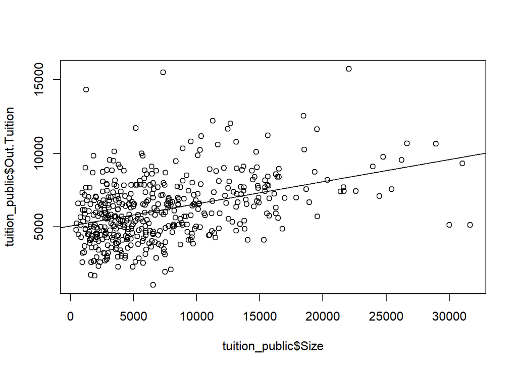

```r
  plot(tuition_public$Size, tuition_public$Out.Tuition)
  abline(sz_pu)
```

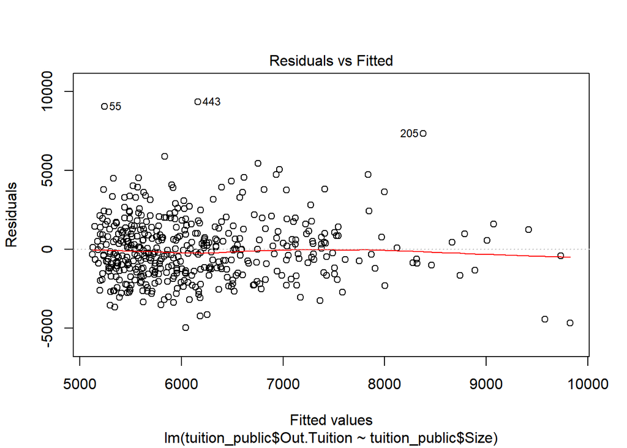

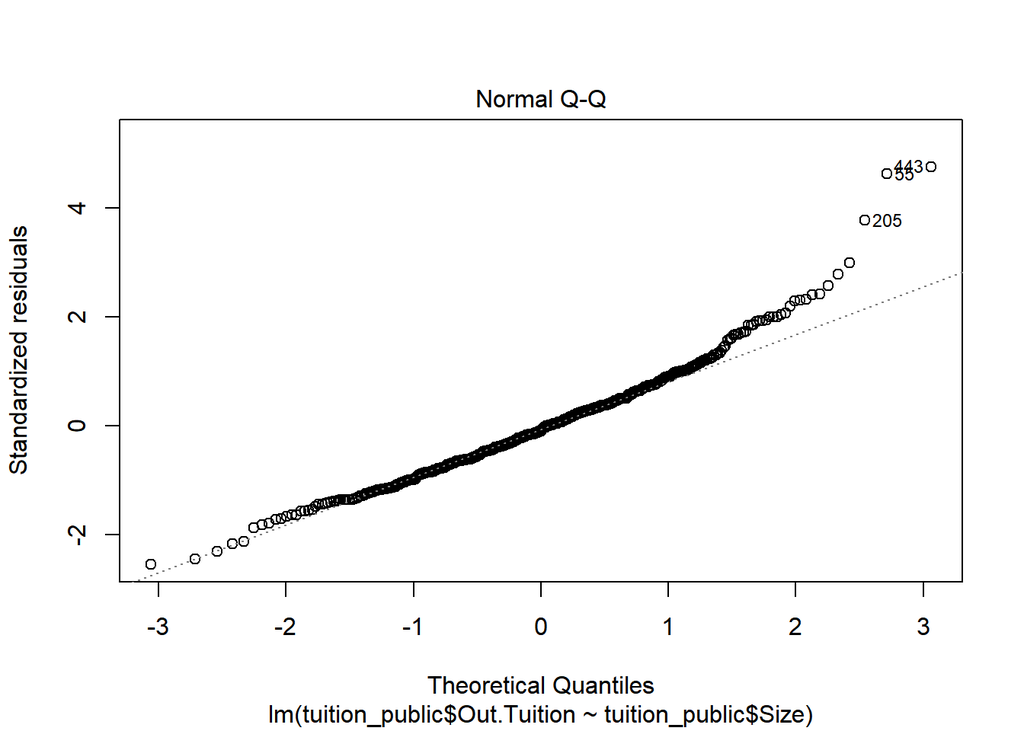

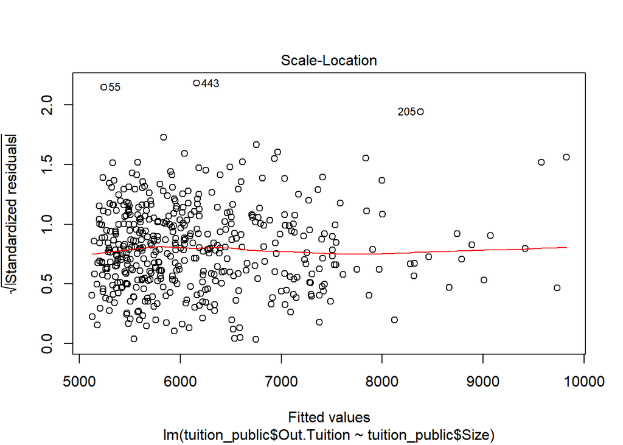

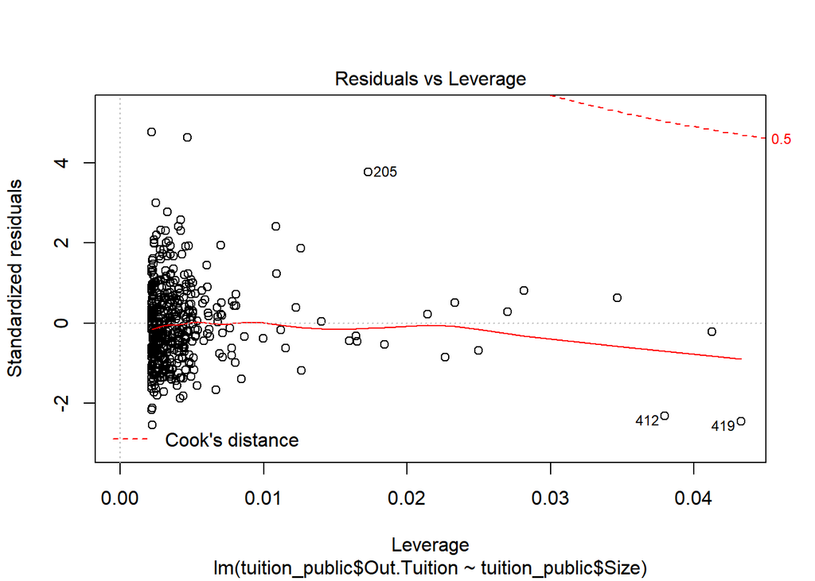

```r
  plot(sz_pu)
```

```r
  tuition_private = tuition[tuition$Public == 2, ]
  sz_pr = lm(tuition_private$Out.Tuition ~ tuition_private$Size)
  summary(sz_pr)
```

```
##
## Call:
## lm(formula = tuition_private$Out.Tuition ~ tuition_private$Size)
##
## Residuals:
##      Min       1Q   Median       3Q      Max
## -19804.4  -2416.1   -328.7   2257.0  14616.7
##
## Coefficients:
##                       Estimate Std. Error t value Pr(>|t|)
## (Intercept)          1.026e+04  1.817e+02  56.449  < 2e-16 ***
## tuition_private$Size 4.342e-01  6.940e-02   6.255 6.37e-10 ***
## ---
## Signif. codes:  0 '***' 0.001 '**' 0.01 '*' 0.05 '.' 0.1 ' ' 1
##
## Residual standard error: 3922 on 823 degrees of freedom
##   (7 observations deleted due to missingness)
## Multiple R-squared:  0.04539,    Adjusted R-squared:  0.04423
## F-statistic: 39.13 on 1 and 823 DF,  p-value: 6.366e-10
```